# task3

Mattia Storero

24/10/2019

## Background

The data were taken from “https://www.cdc.gov/nchs/data_access/vitalstatsonline.htm”. The dataframes were downloaded, setted and selected thanks to the two guides.

## Working with the data

The data were cleaned fixing the variables and adding the column year for each database. After that, the two databases were merged together vertically in order to work with them.

## Analysis and answering to questions

1-The first point was to find out the proportion of boys and girls. For this reason, we work with the variable “sex”

```
## [1] 0.5117177
```

```
## [1] 0.4882823
```

```
## [1] 1.047996
```

```
## [1] 0.5111813
```

```
## [1] 0.4888187
```

```
## [1] 1.045748
```

It’s easy to see that the two values of boys/girls has changed, but not for a relevant value. In fact, it decreases from 1.047996 to 1.045748. To sum up, the number of girls has increased.

2-The second point was to find out the avarage weight in grams and to see if there were differences between boys and girls in 2018 thanks to a density plot.

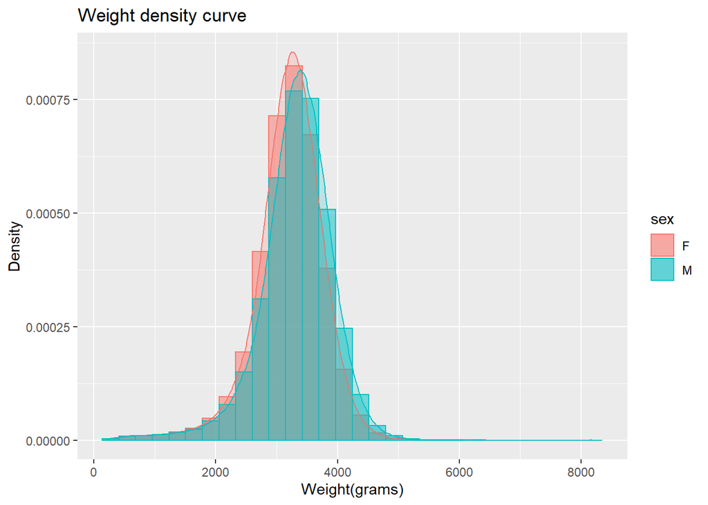

3-The third point was to find out if the average birth weight vary by month and year.

```
##     month avg_weight
##  1:     1   3252.256
##  2:     2   3260.639
##  3:     3   3262.990
##  4:     4   3266.531
##  5:     5   3267.867
##  6:     6   3264.266
##  7:     7   3263.729
##  8:     8   3265.932
##  9:     9   3268.226
## 10:    10   3261.624
## 11:    11   3259.406
## 12:    12   3251.082
```

```
##     month avg_weight
##  1:     1   3253.882
##  2:     2   3262.313
##  3:     3   3265.336
##  4:     4   3268.617
##  5:     5   3268.276
##  6:     6   3266.514
##  7:     7   3263.652
##  8:     8   3267.598
##  9:     9   3262.188
## 10:    10   3256.551
## 11:    11   3254.675
## 12:    12   3249.713
```

It’s possible to see that the annual average weight decreases from 3262.134 to 3261.649, whereas between the months there are relatively bigger differences (but not really relevant).